# FigureYa51TMB_update

Jingze Gao; Ying Ge, Yijing Chen

2025-5-20

# 需求描述

# requirement description

用某个基因的表达量来分组，画出各组的TMB box plot，带散点，计算p value。

Use the expression of a particular gene to group, draw a TMB box plot with scatter points for each group, and calculate the p value.

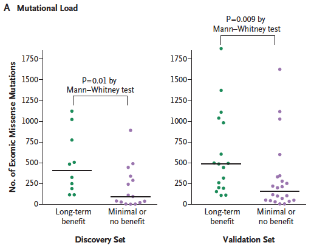

出自https://www.nejm.org/doi/full/10.1056/NEJMoa1406498

fromhttps://www.nejm.org/doi/full/10.1056/NEJMoa1406498

# 应用场景

# application scenario

借助突变数据TMB，把你的基因跟免疫治疗预后联系起来。

可以用某个基因的表达量高低来分组（或根据其他信息分组），对比不同分组的TMB值。

下一步，还可以用TMB值高低来分组，做生存分析。

With the help of mutation data TMB, link your genes to immunotherapy prognosis.

You can group based on high or low expression of a particular gene (or group based on other information) and compare the TMB values of different groups.

In the next step, it is also possible to do survival analysis by grouping with high or low TMB values.

# 环境设置

# environment setting

加载R包

Load R package

```r
library(TCGAbiolinks)
library(dplyr)
```

```r
library(stringr)
library(ggplot2)
library(ggpubr)

Sys.setenv(LANGUAGE = "en") #显示英文报错信息 display English error messages
options(stringsAsFactors = FALSE) #禁止chr转成factor prohibit the conversion of chr to factor
```

# 用表达量分组

# Group with expressions

如果你的分组信息已经保存成`easy_input_group.csv`的格式，就可以跳过这步，直接进入“输入文件”。

If your grouping information has been saved as `easy_input_group.csv`, you can skip this step and go directly to the `Input file`.

## 从TCGA下载表达数据

## Download expression data from TCGA

如果你已经有表达数据，就可以跳过这步，直接进入“根据表达量给sample分组”

If you already have expression data, you can skip this step and go directly to “Group sample based on expression”

```r
expquery <- GDCquery(project = "TCGA-LIHC",
                data.category = "Transcriptome Profiling",
                data.type = "Gene Expression Quantification",
                workflow.type = "STAR - Counts")
GDCdownload(expquery)
expquery2 <- GDCprepare(expquery)
expMatrix <- TCGAanalyze_Preprocessing(expquery2)
dim(expMatrix)
expMatrix[1:3,1:4]

#只取肿瘤组织
#take only tumor tissue
group_list <- ifelse(substr(colnames(expMatrix),14,14)=='0','tumor','normal')
expMatrix_tumor <- expMatrix[,group_list=='tumor']
dim(expMatrix_tumor)

#保存一个基因的表达量，此处选取TP53，对应ID为ENSG00000141510
#save the expression of a gene, TP53 is selected here, corresponding to the ID of ENSG00000141510
rownames(expMatrix_tumor) <- sapply(strsplit(rownames(expMatrix_tumor), "\\."), function(x) x[1])
write.csv(expMatrix_tumor["ENSG00000141510",], "easy_input_expr.csv", quote=F, row.names = T)
```

## 根据表达量给sample分组

## Group sample based on expression

easy_input_expr.csv，某个基因在各个sample里的表达量。

第一列是sample ID，与突变数据里的sample ID一致；第二列是基因的表达量。

easy_input_expr.csv, the expression amount of a gene in each sample.

The first column is the sample ID, which corresponds to the sample ID in the mutation data; the second column is the expression amount of the gene.

```r
myGene <- read.csv("easy_input_expr.csv")
colnames(myGene) <- c("Tumor_Sample_Barcode","Expr") #改列名 modify the column name
#保留barcode的前三个label
#keep the first three labels of the barcode
myGene$Tumor_Sample_Barcode <- str_sub(myGene$Tumor_Sample_Barcode,1, 12)
head(myGene)
```

```
##   Tumor_Sample_Barcode Expr
## 1         TCGA-2V-A95S 1908
## 2         TCGA-2Y-A9GS 2479
## 3         TCGA-2Y-A9GT  618
## 4         TCGA-2Y-A9GU  724
## 5         TCGA-2Y-A9GV  465
## 6         TCGA-2Y-A9GW 2035
```

```r
# 用表达量中值分为两组
# divided into two groups using the median expression
myGene$Expr_level <- ifelse(myGene$Expr > median(myGene$Expr),"high","low")
write.csv(myGene[,c(1,3)], "easy_input_group_2.csv", quote = F, row.names = F)

# 或者自己定义cutoff，分为更多组，例如三组
# or define your own cutoff and divide into more groups, e.g. three groups
cutoff_low <- 3
cutoff_high <- 8
myGene$Expr_level <- cut(myGene$Expr, breaks = c(-Inf, cutoff_low, cutoff_high, Inf), labels = c("low","med","high"))
write.csv(myGene[,c(1,3)], "easy_input_group_3.csv", quote = F, row.names = F)
```

# 输入文件

# Input file

需要TMB和分组文件（两组或更多组）。

mutation-load.txt，TCGA的TMB，来源于2018年的这篇文献：The Immune Landscape of Cancer https://pubmed.ncbi.nlm.nih.gov/29628290/，我们直接拿来用就好。

TMB and grouping files (two or more groups) are needed.

mutation-load.txt, TCGA’s TMB, is derived from this 2018 paper, The Immune Landscape of Cancer https://pubmed.ncbi.nlm.nih.gov/29628290/, which we’ll just use directly.

```r
# 加载分组
# 分两组的情况
# load grouping
# divide into two groups
myGroup <- read.csv("easy_input_group_2.csv")
myGroup$Expr_level <- factor(myGroup$Expr_level, levels = c("low", "high"))

# 分三组的情况
# divide into three groups
#myGroup <- read.csv("easy_input_group_3.csv")
#myGroup$Expr_level <- factor(myGroup$Expr_level, levels = c("low", "med", "high"))
head(myGroup)
```

```
##   Tumor_Sample_Barcode Expr_level
## 1         TCGA-2V-A95S       high
## 2         TCGA-2Y-A9GS       high
## 3         TCGA-2Y-A9GT        low
## 4         TCGA-2Y-A9GU        low
## 5         TCGA-2Y-A9GV        low
## 6         TCGA-2Y-A9GW       high
```

```r
# 加载TMB
# load TMB
myMut <- data.table::fread("mutation-load.txt",data.table = F)
# 其中Non-silent per Mb是TMB
# among them, Non-silent per Mb is TMB
head(myMut)
```

```
##   Cohort   Patient_ID Tumor_Sample_ID Silent per Mb Non-silent per Mb
## 1    ACC TCGA-OR-A5JR TCGA-OR-A5JR-01    0.05168695        0.05168695
## 2    ACC TCGA-OR-A5JH TCGA-OR-A5JH-01    0.10244018        0.15366028
## 3    ACC TCGA-OR-A5JQ TCGA-OR-A5JQ-01    0.08117102        0.16234204
## 4    ACC TCGA-OR-A5L9 TCGA-OR-A5L9-01    0.05354531        0.16063592
## 5    ACC TCGA-OR-A5LA TCGA-OR-A5LA-01    0.05456403        0.19097410
## 6    ACC TCGA-OR-A5LH TCGA-OR-A5LH-01    0.02618618        0.20948946
```

```r
# 合并
# merge
TMB_clinical_mRNA <- myGroup %>%
  inner_join(myMut,by = c("Tumor_Sample_Barcode" = "Patient_ID")) %>%
  rename(TMB = 'Non-silent per Mb' )
head(TMB_clinical_mRNA)
```

```
##   Tumor_Sample_Barcode Expr_level Cohort Tumor_Sample_ID Silent per Mb      TMB
## 1         TCGA-2Y-A9GS       high   LIHC TCGA-2Y-A9GS-01     0.3374325 1.542548
## 2         TCGA-2Y-A9GU        low   LIHC TCGA-2Y-A9GU-01     0.9778646 3.275847
## 3         TCGA-2Y-A9GX       high   LIHC TCGA-2Y-A9GX-01     0.3650348 1.216783
## 4         TCGA-2Y-A9GY       high   LIHC TCGA-2Y-A9GY-01     0.5069560 1.569150
## 5         TCGA-2Y-A9GZ        low   LIHC TCGA-2Y-A9GZ-01     0.7030879 1.988042
## 6         TCGA-2Y-A9H0        low   LIHC TCGA-2Y-A9H0-01     0.3867021 1.691822
```

# 开始画图

# Start drawing

用ggplot2画图，用ggpubr算p value。

Use ggplot2 to draw the graph, use ggpubr to calculate the p value.

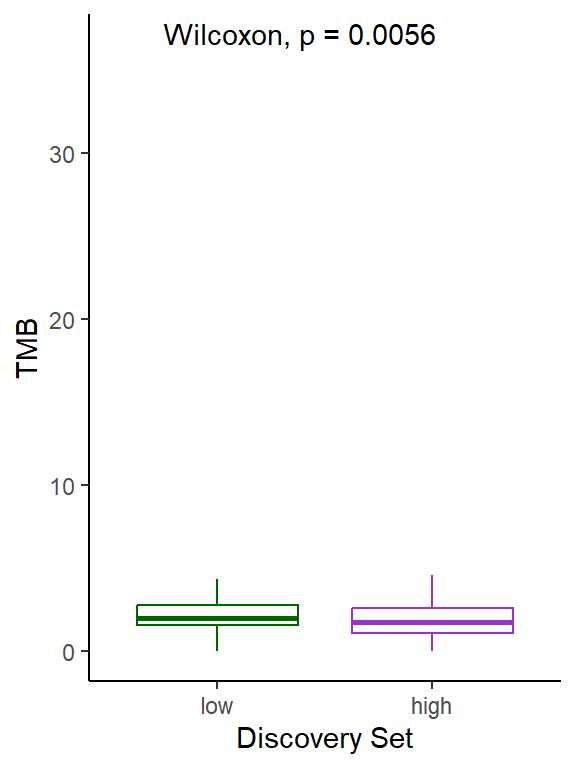

```r
mycol <- c("darkgreen", "darkorchid3", "orange") #与分组数量一致 consistent with the number of groups
p <- ggplot(TMB_clinical_mRNA, aes(x = Expr_level, y = TMB, color = Expr_level)) +
  geom_boxplot(outlier.color = NA) + #隐去箱线图上的异常点 hide the abnormal points on the box plot

  scale_color_manual(values = mycol) + #自定义配色 custom color scheme

  stat_compare_means(#paired = T, #whether you want a paired test
                     #两组对比，用wilcox.test或t.test comparison between two groups using wilcox.test or t.test
                     method = "wilcox.test",

                     #多组对比，用kruskal.test或anova multiple group comparisons using kruskal.test or anova
                     #method = "kruskal.test",
                     label.y = max(TMB_clinical_mRNA$TMB)*1.1) + #label的位置 the position of label

  theme_bw() + #去除背景色 remove background color
  theme(panel.grid =element_blank()) + #去除网格线 remove gridlines
  theme(panel.border = element_blank()) + #去除外层边框 remove outer border
  theme(axis.line = element_line(colour = "black")) + #沿坐标轴显示直线 display line along coordinate axis
  xlab("Discovery Set") +
  #ylim(0,5) + #设置Y轴范围 set the Y-axis range
  guides(color=FALSE) #不显示图例 legend is not displayed
p
```

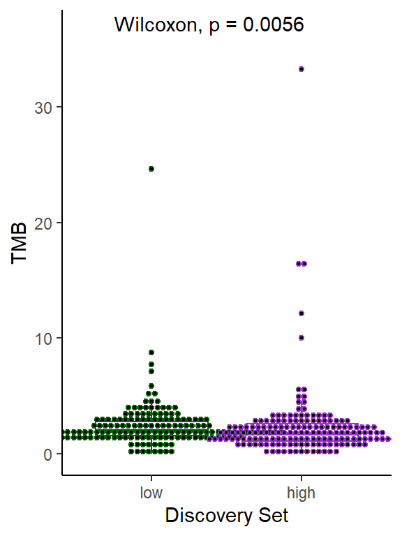

```r
# 绘制Wikinson点图
# draw Wikinson dot plot
p + geom_dotplot(binaxis = "y", #沿y轴堆积，并沿着x轴分组 stack along the y-axis and group along the x-axis
               binwidth = 0.5, #最大组距 maximum group distance
               dotsize = 1, #点的大小 size of the point
               #如果点太多，两组叠在一起，就需要运行下面这行把它们分开
               #if there are too many points and the two groups overlap, you need to run the following line to separate them
               #stackgroups = T, binpositions="all",
               stackdir = "center")  #数量保持一致的中心堆叠方式 center stacking method with consistent quantity
```

```r
ggsave("TMB_dot.pdf")
```

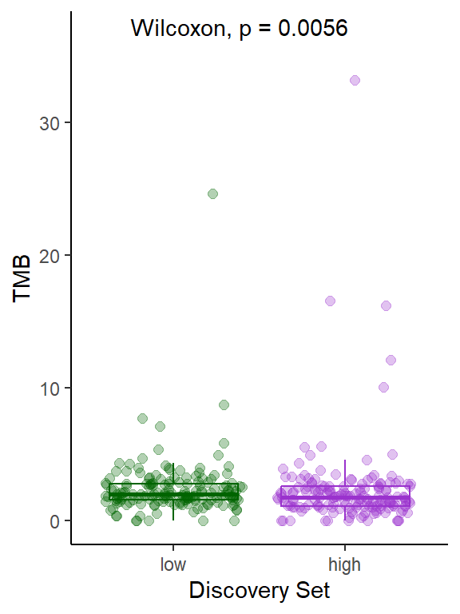

```r
# 或者散点图
# or scatter plot
p + geom_point(aes(group = Expr_level),
             alpha=.3, #点太多，设为透明色，就能看到叠加效果 too many points, set them to transparent color to visualize the overlay effect
             size = 2, #点的大小 size of the point
             position="jitter") #分散 disperse
```

```r
ggsave("TMB_point.pdf")
```